# Sydney Airbnb Price Classification

Predicting Budget, Mid-Market & Premium Properties

Group W14_G03

October 27, 2025

# Our Data Science Journey

**Project Topic:** Sydney Airbnb Price Classification

**The Team Challenge:**

Can we predict whether a Sydney Airbnb will be Budget (<$100), Mid-Market ($100-$200), or Premium (>$200) based on property features?

**Why This Matters:**

- Helps property investors make smart decisions
- Guides hosts in pricing strategies
- Informs tourism planning in Sydney
- Provides insights into housing affordability

# Research Question & Impact

## The Big Question

**Can we predict Airbnb price categories using property characteristics, location, and host factors?**

## Why Should You Care?

**For Travelers:** Find the right accommodation in your budget

**For Property Owners:** Understand what drives premium pricing

**For Sydney:** Insights into short-term rental market dynamics

**For Policy Makers:** Evidence-based housing policy decisions

# The Data Story

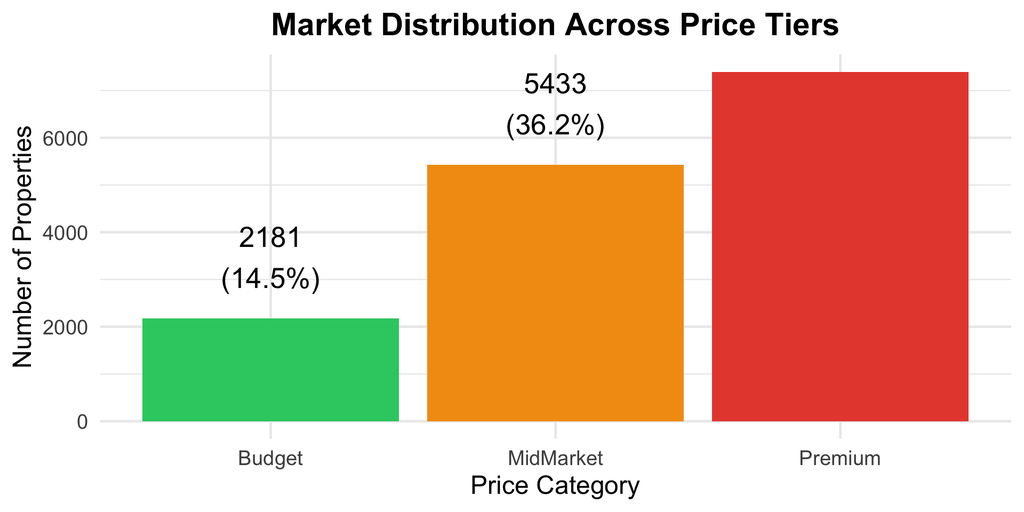

# How We Cleaned The Data

## The Messy Reality

- **18,187 raw listings** with 79 different features
- Missing values in reviews, bathrooms, host details
- Price data with symbols ($, commas)
- Extreme outliers (properties >$1,000/night)

## Our Cleaning Process

1. **Removed formatting** from price data
2. **Handled missing values** using smart imputation
3. **Filtered outliers** beyond $1,000/night
4. **Created new features** from existing data

# Feature Engineering: Creating Useful Variables

## Why Create New Features?

Raw data doesn’t always capture what matters. We engineered 6 new features:

## Derived Variables

**From Location Data:** - `distance_from_cbd` - Calculated from latitude/longitude using Sydney CBD coordinates - `is_popular_area` - TRUE if in Bondi, Manly, CBD, Darlinghurst, or Surry Hills

**From Property Data:** - `property_size` - Categorized as Small/Medium/Large/Extra Large based on guest capacity - `amenities_count` - Count of amenities from the amenities list

**From Host Data:** - `host_experience` - Single Property / Small Portfolio / Large Portfolio - `availability_level` - Low/Medium/High based on days available per year

These capture **business logic** that raw numbers miss!

# Feature Selection: Why These 19 Features?

## From 79 Features → 19 Features

**Selection Criteria:**

1. **Relevance to Pricing** - Does this affect what people pay?
2. **Data Quality** - Is the feature reliable and complete?
3. **Avoid Redundancy** - Don’t include highly correlated features
4. **Business Interpretability** - Can we explain this to stakeholders?

## Our 19 Final Features

**Property Characteristics (10):** accommodates, bedrooms, bathrooms, property_type, room_type, amenities_count, property_size, minimum_nights, availability_365, availability_level

**Location (3):** neighbourhood_cleansed, distance_from_cbd, is_popular_area

**Host Quality (4):** host_is_superhost, host_identity_verified, host_listings_count, host_experience

**Social Proof (2):** number_of_reviews, review_scores_rating

# What Does Our Data Look Like?

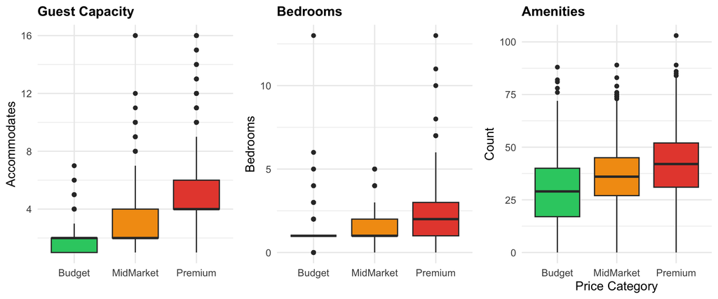

**Key Pattern:** Premium properties have more bedrooms, accommodate more guests, and offer more amenities.

# Where Are The Properties?

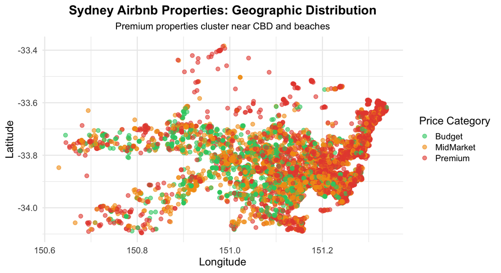

# Location Matters!

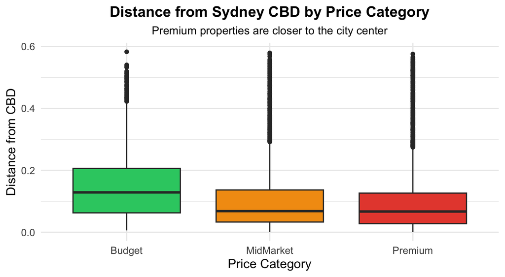

**Discovery:** Location is a MAJOR pricing driver!

# Room Type Tells a Story

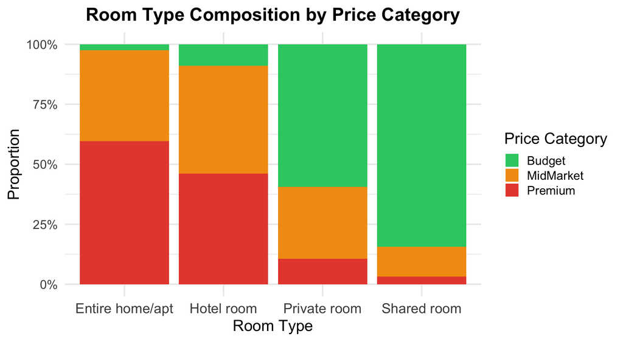

**Insight:** Entire homes/apartments dominate Premium category; shared rooms are mostly Budget.

# Our Machine Learning Approach

## Five Models Tested

| Model | Why We Chose It |
| --- | --- |
| **Logistic Regression** | Simple, interpretable baseline |
| **Random Forest** | Handles complex patterns, multiple features |
| **Support Vector Machine** | Creates smart decision boundaries |
| **Linear Discriminant Analysis** | Efficient, reduces dimensions |
| **K-Nearest Neighbors** | Leverages geographic patterns |

## Training Strategy

- **70% training / 30% testing split**
- **5-fold cross-validation** with 3 repetitions
- **Hyperparameter tuning** for optimal performance

# Model Performance: The Results!

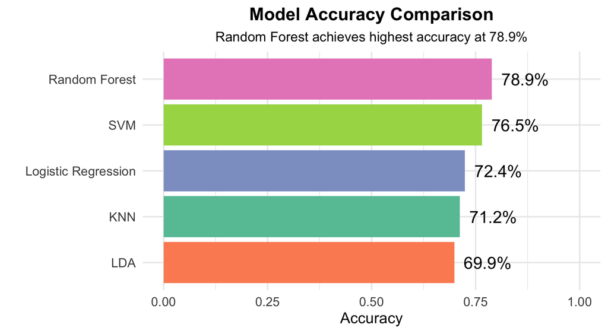

**Winner: Random Forest with 78.9% accuracy!**

# What Features Matter Most?

## Top 5 Pricing Predictors (from Random Forest)

1. **Distance from CBD** - Location is king!
2. **Number of Bedrooms** - Size matters
3. **Accommodates (Guest Capacity)** - Bigger = pricier
4. **Neighbourhood** - Bondi, Manly, CBD command premium
5. **Amenities Count** - More amenities, higher price

## Surprising Findings

- **Superhost status** influences pricing significantly
- **Room type** is a stronger predictor than property type
- **Geographic clustering** very pronounced in Sydney

# Model Performance By Category

[figure not shown]

# Challenges We Faced

## The Difficult Parts

**1. Class Imbalance**

**2. Boundary Ambiguity**

- Properties near $100 and $200 thresholds are tricky
- Natural overlap in features between adjacent tiers

**4. Missing Data**

- Reviews, bathrooms, host info often missing
- Required smart imputation strategies

# Limitations & What We’d Do Differently

## Study Limitations

**Data Constraints:**

- Single snapshot in time (no seasonal trends)
- Self-reported prices may not reflect actual bookings
- Sydney-specific patterns may not generalize

**Feature Limitations:**

- No actual booking/revenue data
- No review sentiment analysis
- Fixed price boundaries ($100, $200)

## Future Improvements

1. **Time series modeling** for seasonal patterns
2. **Text analysis** of reviews and descriptions
3. **Dynamic pricing** predictions
4. **Multi-city comparison** (Melbourne, Brisbane)

# Key Insights & Takeaways

## What We Learned

**1. Location is King** Properties within 5km of CBD command 2-3x premium over outer suburbs

**2. Size Matters** Each additional bedroom increases likelihood of Premium classification by ~40%

**3. Machine Learning Works** Achieved **79% accuracy** - vastly better than random guessing (33%)

**4. Market Segmentation is Clear** Three-tier classification aligns with natural market behavior

**5. Geographic Patterns** Premium properties cluster in Bondi, Manly, CBD, and harbour areas

# Practical Recommendations

## For Property Investors

- **Location first:** CBD proximity is the #1 driver
- **Add bedrooms** to move from Budget to Mid-Market tier
- **Amenity upgrades** have diminishing returns for Budget tier

## For Airbnb Hosts

- **Use predictions** to anchor competitive pricing
- **Superhost status** matters - invest in service quality
- **Premium requires complete amenity packages**

# Linking Back to Our Research Question

## Research Question Revisited

> Can we predict whether a Sydney Airbnb property will be classified as Premium, Mid-Market, or Budget based on property characteristics, location and host factors?

## Our Answer: **YES!**

**Bottom Line:** Machine learning successfully predicts Airbnb price categories, providing actionable insights for investors, hosts, and policymakers in Sydney’s short-term rental market.

# Thank You!

## Questions?

**Our Journey:**

- 18,000+ Airbnb listings analyzed
- 5 machine learning models trained
- 79% prediction accuracy achieved
- Clear insights for Sydney’s rental market

**Key Takeaway:** Data science can transform complex housing data into practical decision-support tools

**Group W14_G03**

**STAT5003 - Computational Statistical Methods**

**University of Sydney | 2025**